# FRT CI Package Tutorial

Bertling, M., Ding, P., Feller, A., and Miratrix, L.

2018-11-21

# Introduction

This document demonstrates how to perform permutation test inference for heterogeneous treatment effects. We use a simulated dataset to illustrate. This data is provided with the package as ‘ToyData’. Overall, this vignette illustrates the different tests for ideosyncratic variation one might make using our package, and shows how different forms of covariate adjustment can increase power or target inferential questions differently.

We first load our package along with some other useful packages.

```r
library( mvtnorm )
library( tidyverse )
library( FRTCI )
data( ToyData )
```

# The illustrative Dataset

We begin with exploring a toy dataset with 500 observations that we included with the package for illustration. `ToyData` has an outcome, four covariates, and a treatment indicator. They were generated with the following model:
$$Y_i(0) = 1 + x_{1i} + 2 x_{2i} + 4x_{3i} + \epsilon_i$$
with $\epsilon_i \sim N( 0, 1^2 )$. The treatment model is all systematic:
$$\tau_i = 2 + 2x_{1i} + x_{2i}$$
So $x_1$ and $x_2$ are both predictive of treatment impact. $x_3$ also predicts control side variation, and should therefore be useful for increasing precision. $x_4$ is useless. $Y_i(1) = Y_i(0) + \tau_i$, so there is no ideosyncratic variation if we control for both $x_1$ and $x_2$.

As we generated these data, we know the true individual treatment effects.

```r
data( ToyData )
head( ToyData )
```

```
##           Y Z         x1        x2          x3         x4      tau
## 1 2.2430188 0  0.7635779 0.9415463 -0.50291814 -1.4374786 4.468702
## 2 0.3997241 0 -0.5884278 0.7976774 -0.32835669 -0.7140096 1.620822
## 3 3.5865779 0  0.4881701 0.1335321  0.54933171 -0.7098844 3.109872
## 4 0.9929092 0  1.3796253 0.1786193 -0.23264879 -0.3467998 4.937870
## 5 3.0077115 1  0.1722719 0.2836023 -0.03172434 -2.2100810 2.628146
## 6 2.5547212 0 -0.2978002 0.2678954  0.46776121 -1.6495943 1.672295
```

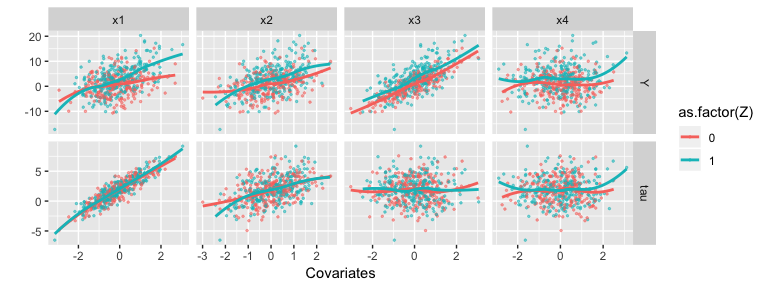

```r
td = gather( ToyData, x1, x2, x3, x4, key="X", value="value" )
td = gather( td, Y, tau, key="outcome", value="value2" )
ggplot( td, aes( x=value, y=value2, col=as.factor(Z) ) ) +
        facet_grid( outcome ~ X, scales="free" ) +
        geom_point( alpha=0.5, size=0.5) +
        geom_smooth( method="loess", se=FALSE ) +
        labs( x="Covariates", y="" )
```

As the data is simulated, we have the true finite-sample ATE:

```r
mean( ToyData$tau )
```

```
## [1] 1.858165
```

Before testing, we quickly look at the marginal and residual CDFs of treatment and control. We see heterogeniety at left, but after controlling for observed covariates we have no visibile ideosyncratic heterogeniety left over.

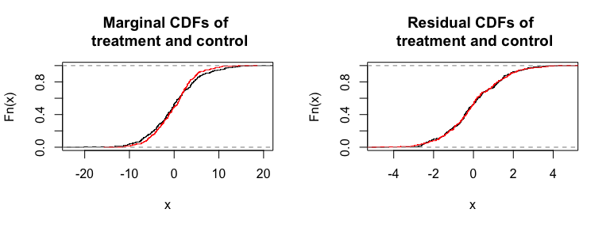

```r
par( mfrow=c(1,2) )
ll0 = lm( Y ~ Z, data=ToyData )
plot( ecdf( resid(ll0)[ToyData$Z==1] ), pch=".", main="Marginal CDFs of \n treatment and control")
plot( ecdf( resid(ll0)[ToyData$Z==0] ), pch=".", col="red", add=TRUE )

ll1 = lm( Y ~ Z + x1 + x2 + x3 + x4, data=ToyData )
plot( ecdf( resid(ll1)[ToyData$Z==1] ), pch=".", main="Residual CDFs of \n treatment and control" )
plot( ecdf( resid(ll1)[ToyData$Z==0] ), pch=".", col="red", add=TRUE )
```

A simple linear model should give us our parameters from above, since it is a correct specification in this case.

```r
M0 <- lm( Y ~ Z * (x1+x2+x3), data=ToyData )
round( coef( M0 ), digits=1 )
```

```
## (Intercept)           Z          x1          x2          x3        Z:x1
##         1.0         2.1         1.1         2.0         4.0         2.0
##        Z:x2        Z:x3
##         0.9         0.1
```

# Testing for ideosyncratic treatment effect variation

## Basic case: no covariate adjustment

To do our tests, we first must specify some parameters determining the resolution of the grid search and number of permutations at each grid point. Note that these values should be increased for a real analysis. We chose these particular values to reduce computation time for illustration.

```r
B <- 100
grid.size = 21
```

The basic test for ideosyncratic treatment effect variation is as follows (with no adjustment for covariates):

```r
tst1 = fishpidetect( Y ~ Z, data=ToyData, B=B, grid.size = grid.size, verbose=FALSE )
print( tst1 )
```

```
##   FRT CI Test for Tx Effect Heterogeneity with test.stat
## data:  500 observations
## t = 0.08 , p-value = 0.1301  (plug =  0.0401 )
##  p-value range = 0.0401 - 0.1301
## CI range =  0.3473426 - 3.936448     MOE = 1.794553
##  Neyman Difference point estimate of average = 2.141895  SE = 0.4612544
##  # tested points = 21
##  B =  100    gamma =  1e-04
```

# Adjusting for covariates

We can increase the power by adjusting for covariates. Please note that we do not include any interaction terms at this point.

We specify a `control.formula` which will be used to generate a matrix to hand to the linear regression function. This will convert factors to dummy variables as needed.

```r
tst2 = fishpidetect( Y ~ Z, data=ToyData, control.formula = ~ x1 + x2 + x3 + x4, B=B, test.stat=SKS.stat.cov,
              verbose=FALSE )
print( tst2 )
```

```
##   FRT CI Test for Tx Effect Heterogeneity with test.stat
## data:  500 observations
## t = 0.232 , p-value = 1e-04  (plug =  1e-04 )
##  p-value range = 1e-04 - 1e-04
## CI range =  1.441206 - 2.454906  MOE = 0.5068501
##  Neyman Difference point estimate of average = 1.948056  SE = 0.1302758
##  # tested points = 151
##  B =  100    gamma =  1e-04
```

Let’s explore how the results might differ when non-treatment covariates are used.

```r
tst2b = fishpidetect( Y ~ Z, data=ToyData, control.formula = ~ x3 + x4, B=B, test.stat=SKS.stat.cov,
              verbose=FALSE )
print( tst2b )
```

```
##   FRT CI Test for Tx Effect Heterogeneity with test.stat
## data:  500 observations
## t = 0.148 , p-value = 1e-04  (plug =  1e-04 )
##  p-value range = 1e-04 - 1e-04
## CI range =  1.047639 - 3.444855  MOE = 1.198608
##  Neyman Difference point estimate of average = 2.246247  SE = 0.3080786
##  # tested points = 151
##  B =  100    gamma =  1e-04
```

We can compare to when we correct for some useless covariates not related to outcome.

```r
N = nrow(ToyData)
ToyData$Xfake = rnorm( N )
tst1b = fishpidetect( Y ~ Z, data=ToyData, control.formula = ~ Xfake, B=B, test.stat=SKS.stat.cov,
              verbose=FALSE )
print( tst1b )
```

```
##   FRT CI Test for Tx Effect Heterogeneity with test.stat
## data:  500 observations
## t = 0.072 , p-value = 0.3401  (plug =  0.2301 )
##  p-value range = 0.2001 - 0.3401
## CI range =  0.3359494 - 3.922934     MOE = 1.793492
##  Neyman Difference point estimate of average = 2.129442  SE = 0.4609819
##  # tested points = 151
##  B =  100    gamma =  1e-04
```

## Ideosyncratic variation beyond systematic variation

To test for ideosyncratic variation beyond systematic, we pass an `interaction.formula` to the method.

We first test for ideosyncratic variation beyond x1 (and we should get high $p$-value).

```r
B = 20

tst3a1 = fishpidetect( Y ~ Z, data=ToyData, interaction.formula = ~ x1, B=B, test.stat=SKS.stat.int.cov,
              verbose=FALSE )
print( tst3a1 )
```

```
##   FRT CI Test for Tx Effect Heterogeneity Beyond a Systematic Model with test.stat
## data:  500 observations
## t = 0.072 , p-value = 0.3501  (plug =  0.2001 )
##  p-value range = 0.0501 - 0.3501
##  # tested points = 151
##  B =  20     gamma =  1e-04
##  Corrected for
```

Include additional terms to increase power. We are correcting for x3 and x4.

```r
tst3a2 <- fishpidetect( Y ~ Z, data=ToyData,
                        interaction.formula = ~ x1,
                        control.formula = ~ x3 + x4,
                        B=B, test.stat=SKS.stat.int.cov,
              verbose=FALSE )
print( tst3a2 )
```

```
##   FRT CI Test for Tx Effect Heterogeneity Beyond a Systematic Model with test.stat
## data:  500 observations
## t = 0.128 , p-value = 1e-04  (plug =  1e-04 )
##  p-value range = 1e-04 - 1e-04
##  # tested points = 151
##  B =  20     gamma =  1e-04
##  Corrected for
##  Adjusted for x3 x4
```

For comparison, we next include all terms.

```r
tst3a2b <- fishpidetect( Y ~ Z, data=ToyData, control.formula = ~ x2 + x3 + x4,
                         interaction.formula = ~ x1, B=B, test.stat=SKS.stat.int.cov,
              verbose=FALSE )
print( tst3a2b )
```

```
##   FRT CI Test for Tx Effect Heterogeneity Beyond a Systematic Model with test.stat
## data:  500 observations
## t = 0.12 , p-value = 1e-04  (plug =  1e-04 )
##  p-value range = 1e-04 - 1e-04
##  # tested points = 151
##  B =  20     gamma =  1e-04
##  Corrected for
##  Adjusted for x2 x3 x4
```

### Testing for ideosyncratic variation.

Now correct for the other covariates as well, but still have correct heterogeneous treatment model. Note that you should still get high $p$-value.

Start testing for variation beyond x1 and x2.

```r
tst3b <- fishpidetect( Y ~ Z, data=ToyData,
                         interaction.formula = ~ x1 + x2, B=B, test.stat=SKS.stat.int.cov,
              verbose=FALSE )
print( tst3b )
```

```
##   FRT CI Test for Tx Effect Heterogeneity Beyond a Systematic Model with test.stat
## data:  500 observations
## t = 0.044 , p-value = 1.0001  (plug =  0.9501 )
##  p-value range = 0.8001 - 1.0001
##  # tested points = 151
##  B =  20     gamma =  1e-04
##  Corrected for x1 x2
```

Continue to test for ideosyncratic variation beyond x1 and x2, adjusting for x3 and x4. Note that you should still get high $p$-value.

```r
tst3c <- fishpidetect( Y ~ Z, data=ToyData,
                         interaction.formula = ~ x1 + x2,
                       control.formula = ~ x3 + x4,
                       B=B, test.stat=SKS.stat.int.cov,
              verbose=FALSE )
print( tst3c )
```

```
##   FRT CI Test for Tx Effect Heterogeneity Beyond a Systematic Model with test.stat
## data:  500 observations
## t = 0.064 , p-value = 0.6001  (plug =  0.3501 )
##  p-value range = 0.2001 - 0.6001
##  # tested points = 151
##  B =  20     gamma =  1e-04
##  Corrected for x1 x2
##  Adjusted for x3 x4
```

Finally, test for ideosyncratic variation beyond all covariates, even irrelevant ones. Again, you should expect to get high $p$-value.

```r
tst3d <- fishpidetect( Y ~ Z, data=ToyData,
                         interaction.formula = ~ x1 + x2 + x3 + x4,
                       B=B, test.stat=SKS.stat.int.cov,
              verbose=FALSE )
print( tst3d )
```

```
##   FRT CI Test for Tx Effect Heterogeneity Beyond a Systematic Model with test.stat
## data:  500 observations
## t = 0.068 , p-value = 0.3501  (plug =  0.2501 )
##  p-value range = 0.1001 - 0.3501
##  # tested points = 151
##  B =  20     gamma =  1e-04
##  Corrected for x1 x2 x3 x4
```

# Display Results

We can easily compare the results by simultaneously displaying the outputs from all tested models by using the `get.p.value()` merthod.

```r
tests = list( no_cov=tst1, useless_cov=tst1b, all_covariates=tst2,
              non_tx_covariates_only=tst2b, het_beyond_x1 = tst3a1,
              het_beyond_x1_with_x3_x4_cov=tst3a2, het_beyond_x1_with_all_cov=tst3a2,
              het_beyond_x1_x2=tst3b,
              het_beyond_x1_x2_with_cov=tst3c, het_beyond_all=tst3d )

agg.res = purrr::map( tests, get.p.value  ) %>%
  purrr::map( as.list )
agg.res = bind_rows( agg.res, .id = "test" )
agg.res
```

```
## # A tibble: 10 x 5
##    test                         p.value   min.p  max.p   plug
##    <chr>                          <dbl>   <dbl>  <dbl>  <dbl>
##  1 no_cov                        0.130  0.0110  0.212  0.0401
##  2 useless_cov                   0.340  0.127   0.442  0.230
##  3 all_covariates                0.0001 0       0.0362 0.0001
##  4 non_tx_covariates_only        0.0001 0       0.0362 0.0001
##  5 het_beyond_x1                 0.350  0.00127 0.592  0.200
##  6 het_beyond_x1_with_x3_x4_cov  0.0001 0       0.168  0.0001
##  7 het_beyond_x1_with_all_cov    0.0001 0       0.168  0.0001
##  8 het_beyond_x1_x2              1.00   0.563   1      0.950
##  9 het_beyond_x1_x2_with_cov     0.600  0.0573  0.809  0.350
## 10 het_beyond_all                0.350  0.0123  0.592  0.250
```

# Cautionary Tale: A linear model with no treatment interaction.

Let’s fit a model that allows for no systematic treatment impact heterogeniety. This means that all variation would have to be considered ideosyncratic. The key, however, is we control for covariates to increase precision.

```r
ll1 = lm( Y ~ Z + x1 + x2 + x3 + x4, data=ToyData )
print( summary( ll1 ) )
```

```
##
## Call:
## lm(formula = Y ~ Z + x1 + x2 + x3 + x4, data = ToyData)
##
## Residuals:
##     Min      1Q  Median      3Q     Max
## -4.8679 -0.9356 -0.0950  1.0347  4.1777
##
## Coefficients:
##             Estimate Std. Error t value Pr(>|t|)
## (Intercept)  1.06905    0.09223  11.591   <2e-16 ***
## Z            1.94806    0.13028  14.953   <2e-16 ***
## x1           2.11124    0.06756  31.251   <2e-16 ***
## x2           2.43679    0.06913  35.251   <2e-16 ***
## x3           3.97462    0.06675  59.547   <2e-16 ***
## x4           0.06023    0.06463   0.932    0.352
## ---
## Signif. codes:  0 '***' 0.001 '**' 0.01 '*' 0.05 '.' 0.1 ' ' 1
##
## Residual standard error: 1.454 on 494 degrees of freedom
## Multiple R-squared:  0.9244, Adjusted R-squared:  0.9236
## F-statistic:  1208 on 5 and 494 DF,  p-value: < 2.2e-16
```

The estimated ATE is close to the truth, as expected considering the random assignment.

Next plot residual CDFS of treatment and control groups.

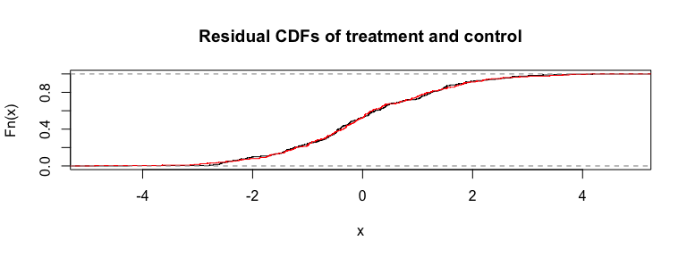

```r
plot( ecdf( resid(ll1)[ToyData$Z==1] ), pch=".", main="Residual CDFs of treatment and control" )
plot( ecdf( resid(ll1)[ToyData$Z==0] ), pch=".", col="red", add=TRUE )
```

Note the residual ECDFs from above are quite aligned. The Tx effect variation has been picked up by main effects which means we would not detect ideosyncratic variation even though there is such variation. This is why the choice of test statistic is delicate.